# Resampling Transition Matrices to Calculate Lambdas

Elizabeth Hiroyasu

August 17, 2016

The popbio package in R has a function to resample projection matrices using a multinomial distribution for the transitions and log normal distribution for fertilities. This effectively allows us to bootstrap a single transition matrix and come up with a vector of population growth rates, which we can then use in the Lotka-Volterra predator prey model.

```r
library(popbio)
```

Building the proejction matrix

```r
stages = c("Juvenile", "SubAdult", "Adult")

p1 =0.69
p2 = 0.468
p3 = 0.449
f2 = 2.535
f3 = 7.775

GopherMatrix = matrix(data=c(0,f2, f3, p1, 0, 0, 0, p2, p3),
              nrow=3, ncol=3, byrow=TRUE,
              dimnames=list(stages,stages))
```

Creating a list of 1000 resampled projection matrices and calculating lambda

Plotting the distribution of lambdas from the resample:

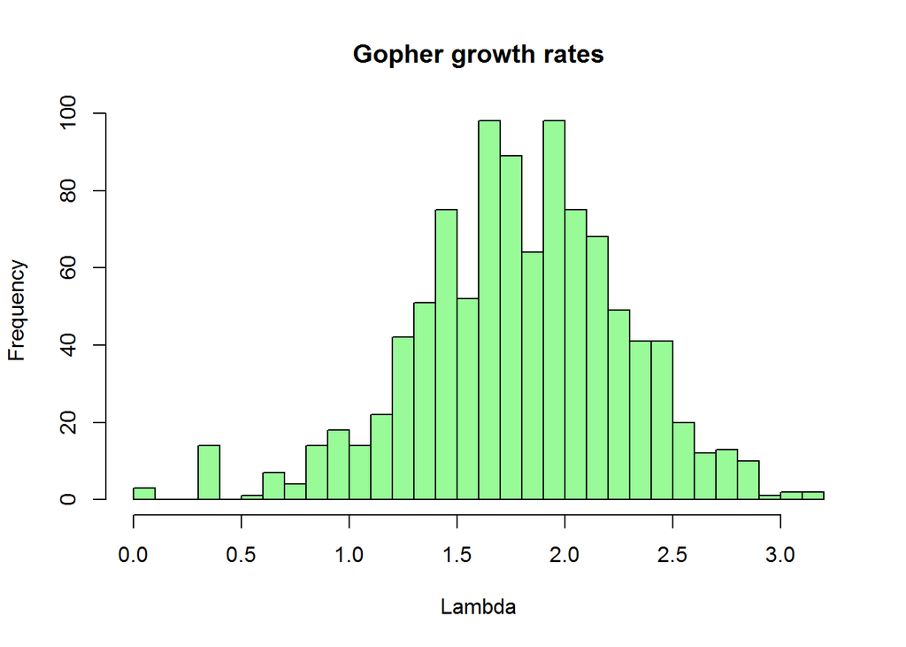

Adding seasonality, data from Andersen and MacMahon, 1981:

```
##          Juvenile SubAdult Adult
## Juvenile      0.0     3.75  3.75
## SubAdult      0.5     0.00  0.00
## Adult         0.0     0.09  0.88
```

```
##          Juvenile SubAdult Adult
## Juvenile      0.0     3.75  3.75
## SubAdult      0.5     0.00  0.00
## Adult         0.0     0.09  0.33
```

```
##          Juvenile SubAdult Adult
## Juvenile      0.0     3.75  3.75
## SubAdult      0.5     0.00  0.00
## Adult         0.0     0.36  0.56
```

```
##          Juvenile SubAdult Adult
## Juvenile      0.0     3.75  3.75
## SubAdult      0.5     0.00  0.00
## Adult         0.0     0.36  0.26
```

```
##          Juvenile SubAdult Adult
## Juvenile      0.0     3.75  3.75
## SubAdult      0.5     0.00  0.00
## Adult         0.0     0.85  0.90
```

```
##          Juvenile SubAdult Adult
## Juvenile      0.0     3.75  3.75
## SubAdult      0.5     0.00  0.00
## Adult         0.0     0.85  0.78
```

Creating a list of 1000 resampled projection matrices and calculating lambda for each year. To preserve the variation seen in each season, I have sampled 1000 matrices from each of the above matrices by season, then multiplied them together to come up with 1000 matrix products for each year.

We are interested in the distribution of the population growth rates resampled from here, we can calculate the set of lambdas for each year using the lambda function from the popbio package. We can then plot their distribution in a histogram. We will also save the data from this run into a csv file for later use with the Lotka Volterra simulations

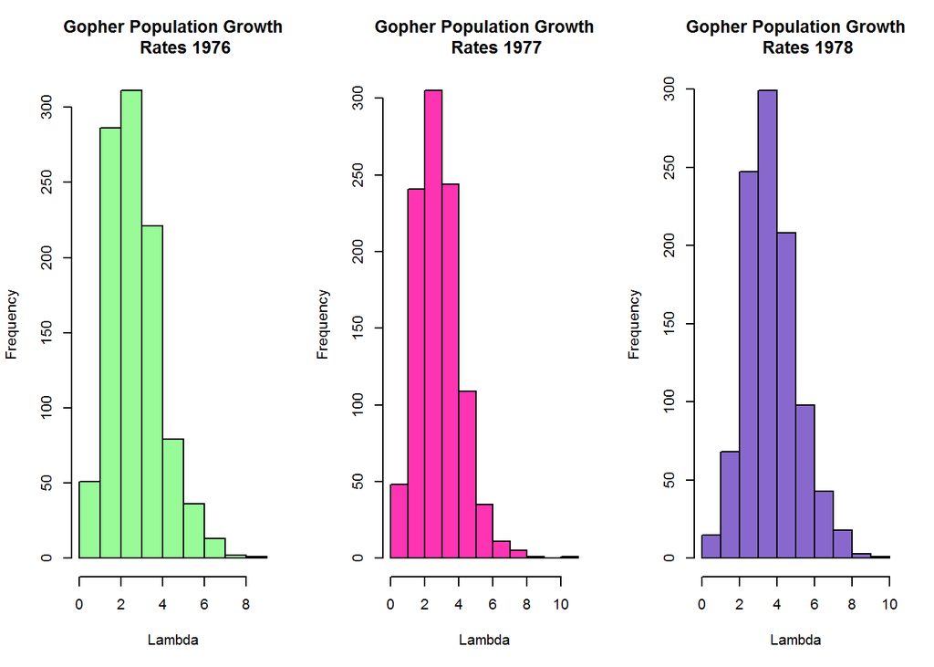